# Introduction

In this project we use two different decision tree models, one using a GINI optimization method, one using an entropy optimization method. The goal is to predict whether a breast tumor is benign or malignant, given 10 features present in an image of the mass.

Data for this project comes from the kaggle dataset found at https://www.kaggle.com/uciml/breast-cancer-wisconsin-data. From the dataset author: "Features are computed from a digitized image of a fine needle aspirate (FNA) of a breast mass. They describe characteristics of the cell nuclei present in the image." From each observation 10 features were extracted, as both mean measures and worst-case measures.

- mean radius
- texture (sd of gray scales)
- perimeter
- area
- smoothness (variation in radius lengths)
- compactness (perimeter^2 / area - 1.0)
- concavity
- concave points
- symmetry
- fractal dimension

# Imports

```python
import pandas as pd
# Import Decision Tree Classifier
from sklearn.tree import DecisionTreeClassifier
# For creating test and train models
from sklearn.model_selection import train_test_split
# Import scikit-learn metrics module for accuracy calculation
from sklearn import metrics
```

# Data

```python
# Load dataset
data = pd.read_csv("breast-cancer.csv")
```

After removing a couple unnecessary columns, we have the following features.

```python
data = data.drop(columns=['id','Unnamed: 32'])
data.head()
```

|  | diagnosis | radius_mean | texture_mean | perimeter_mean | area_mean | smoothness_mean | compactness_mean | concavity_mean | concave points_mean | symmetry_mean | ... | radius_worst | texture_worst | perimeter_worst | area_worst | smoothness_worst | compactness_worst | concavity_worst | concave points_worst | symmetry_worst | fractal_dimension_worst |
| --- | --- | --- | --- | --- | --- | --- | --- | --- | --- | --- | --- | --- | --- | --- | --- | --- | --- | --- | --- | --- | --- |
| 0 | M | 17.99 | 10.38 | 122.80 | 1001.0 | 0.11840 | 0.27760 | 0.3001 | 0.14710 | 0.2419 | ... | 25.38 | 17.33 | 184.60 | 2019.0 | 0.1622 | 0.6656 | 0.7119 | 0.2654 | 0.4601 | 0.11890 |
| 1 | M | 20.57 | 17.77 | 132.90 | 1326.0 | 0.08474 | 0.07864 | 0.0869 | 0.07017 | 0.1812 | ... | 24.99 | 23.41 | 158.80 | 1956.0 | 0.1238 | 0.1866 | 0.2416 | 0.1860 | 0.2750 | 0.08902 |
| 2 | M | 19.69 | 21.25 | 130.00 | 1203.0 | 0.10960 | 0.15990 | 0.1974 | 0.12790 | 0.2069 | ... | 23.57 | 25.53 | 152.50 | 1709.0 | 0.1444 | 0.4245 | 0.4504 | 0.2430 | 0.3613 | 0.08758 |
| 3 | M | 11.42 | 20.38 | 77.58 | 386.1 | 0.14250 | 0.28390 | 0.2414 | 0.10520 | 0.2597 | ... | 14.91 | 26.50 | 98.87 | 567.7 | 0.2098 | 0.8663 | 0.6869 | 0.2575 | 0.6638 | 0.17300 |
| 4 | M | 20.29 | 14.34 | 135.10 | 1297.0 | 0.10030 | 0.13280 | 0.1980 | 0.10430 | 0.1809 | ... | 22.54 | 16.67 | 152.20 | 1575.0 | 0.1374 | 0.2050 | 0.4000 | 0.1625 | 0.2364 | 0.07678 |

5 rows × 31 columns

# Cleaning

Here we can split the dataset into the features and the target variable; the diagnosis.

```python
cols = list(data.columns)
features = cols[1:31]
x = data[features]
y = data.diagnosis
```

Now we can split into 70% training data and 30% test data.

```python
x_train, x_test, y_train, y_test = train_test_split(x, y, test_size=0.3, random_state=1)
```

# Analysis

## Decision Tree using GINI method

We'll start by using the default tree classifier from sklearn. The default tree uses the gini method for determining the best split at each level of the tree. The gini method minimizes the weighted average of (1-(sum of squared possibilites)) for each remaining attribute in the tree.

Here we'll create the tree, train the tree, and predict the responses for the test dataset.

```python
# This creates the tree
basic_tree = DecisionTreeClassifier()
# This trains the tree
basic_tree = basic_tree.fit(x_train,y_train)

# This predicts the response for the test dataset
y_pred = basic_tree.predict(x_test)
```

Now we can use the metrics library from scikitlearn to determine the accuracy, precision and recall of our model on the test data. For our purposes we say that a 'positive' is a malignant tumor, and benign is 'negative.'

```python
print("Accuracy:",metrics.accuracy_score(y_test,y_pred))
print("Precision:",metrics.precision_score(y_test, y_pred,pos_label='M'))
print("Recall:",metrics.recall_score(y_test, y_pred,pos_label='M'))
```

```
Accuracy: 0.9473684210526315
Precision: 0.95
Recall: 0.9047619047619048
```

That's pretty good! Although decision tree models are often prone to overfitting, so we would likely want to use an ensembling technique, or perhaps a random forest model, before using this model on new data.

To display the tree, we can use the graphviz method from scikitlearn's tree library (and a couple other things) to define a function to let us see the tree.

```python
from sklearn.tree import export_graphviz
from sklearn.externals.six import StringIO
from IPython.display import Image
import pydotplus

# Display the decision tree
def displayTree(tree):
    dot_data = StringIO()
    export_graphviz(tree, out_file=dot_data,
                filled=True, rounded=True, impurity=True,
                special_characters=True,feature_names = features,class_names=['0','1'])
    graph = pydotplus.graph_from_dot_data(dot_data.getvalue())
    graph.write_png('breast-cancer-tree.png')
    Image(graph.create_png())
```

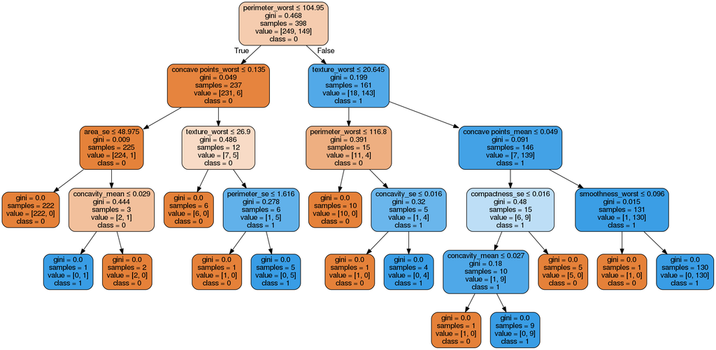

```python
displayTree(basic_tree)
Image('breast-cancer-tree.png')
```

The nice thing about decision tree models is their interpretability. We can see that the measure of the worst perimeter of the mass is the most informative feature for determining whether the tumor is cancerous.

## Decision Tree using Entropy method

Entropy measures information gain, so the goal of this method is to maximize entropy at each level.

Here we build the new model, train it, predict on the test data, and measure the model's accuracy.

```python
entropy_tree = DecisionTreeClassifier(criterion="entropy")

# Train entropy tree
entropy_tree = entropy_tree.fit(x_train,y_train)

# Predict response
y_pred_entropy = entropy_tree.predict(x_test)

# Accuracy
print("Accuracy:",metrics.accuracy_score(y_test, y_pred_entropy))
print("Precision:",metrics.precision_score(y_test, y_pred_entropy,pos_label='M'))
print("Recall:",metrics.recall_score(y_test, y_pred_entropy,pos_label='M'))
```

```
Accuracy: 0.9181286549707602
Precision: 0.8888888888888888
Recall: 0.8888888888888888
```

Entropy achieved slightly lower accuracy, precision, and recall measures than with the gini method, though still respectable. We can view this tree calling the function we defined earlier.

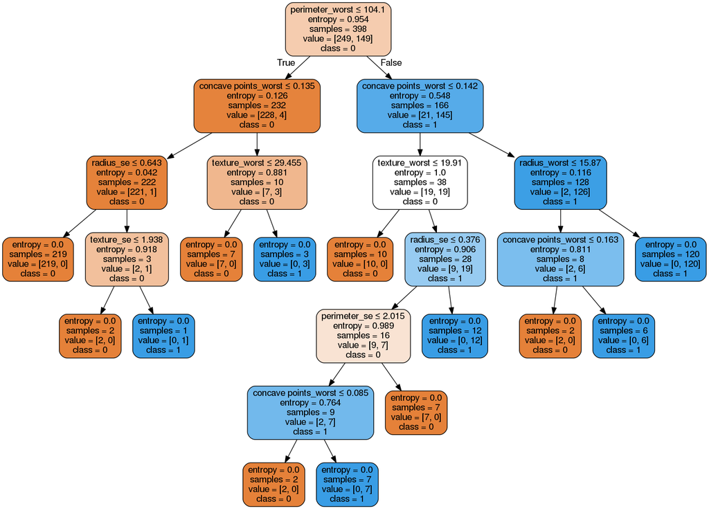

```python
displayTree(entropy_tree)
Image('breast-cancer-tree.png')
```

Again we see that the worst case perimeter was the most informative feature from the breast mass image. Here we saw that the gini method for selecting branching features in a decision tree classifier was slightly more effective than the entropy method on the same data. In further research a random forest classifier could be leveraged to obtain more accurate results.